# Homework 2

DATS 6101 · Fall 2026

Sam Nicholes

2026-09-22

```r
library(nycflights13)
library(tidyverse)
data(flights)
```

# Part 1 · Events are logical vectors (10 points)

https://www.smajhi.com/DATS-6101/homework/hw2.html

## (1a) P(A), P(D), P(A and D)

```r
d <- flights[complete.cases(flights), ] # data set of complete rows stored as d

A <- d$arr_delay > 15 # flights that arrived >15 min late
head(A, 50) # check vector
```

```
##  [1] FALSE  TRUE  TRUE FALSE FALSE FALSE  TRUE FALSE FALSE FALSE FALSE FALSE
## [13] FALSE FALSE  TRUE FALSE FALSE FALSE FALSE FALSE FALSE  TRUE FALSE FALSE
## [25] FALSE  TRUE FALSE FALSE FALSE FALSE FALSE FALSE FALSE  TRUE FALSE FALSE
## [37] FALSE  TRUE FALSE FALSE FALSE FALSE  TRUE FALSE FALSE FALSE FALSE FALSE
## [49] FALSE FALSE
```

```r
D <- d$dep_delay > 15  # flights that departed >15 min late
head(D, 50) # check vector
```

```
##  [1] FALSE FALSE FALSE FALSE FALSE FALSE FALSE FALSE FALSE FALSE FALSE FALSE
## [13] FALSE FALSE FALSE FALSE FALSE FALSE FALSE FALSE FALSE FALSE FALSE FALSE
## [25] FALSE FALSE FALSE FALSE FALSE FALSE FALSE FALSE FALSE FALSE FALSE FALSE
## [37] FALSE FALSE FALSE FALSE FALSE  TRUE FALSE FALSE FALSE FALSE FALSE FALSE
## [49] FALSE FALSE
```

## (1b) P(A or D), two ways

```r
# P(AuD), probability that flight is late by arrival OR by departure

pA <- mean(d$arr_delay > 15, na.rm = TRUE) # P(late arrival)
pD <- mean(d$dep_delay > 15, na.rm = TRUE) # P(late departure)

# By operator '|'
pAuD_opp <- mean(A | D, na.rm = TRUE)

# By additive rule
pAnD_opp <- mean(A & D, na.rm = TRUE) # calculate p(AnD)
pAuD_add <- pA + pD - pAnD_opp # calculate p(AuD) by addititve rule

isTRUE(all.equal(pAuD_opp, pAuD_add)) # vectors are the same mathematically
```

```
## [1] TRUE
```

```r
pAuD_opp == pAuD_add # vectors differ by float-point
```

```
## [1] FALSE
```

```r
print(pAuD_opp, digits = 20)
```

```
## [1] 0.27959406866129415947
```

```r
print(pAuD_add, digits = 20)
```

```
## [1] 0.27959406866129410396
```

## (1c) Neither

The complement of p(AuD) gets us to p(Ac n Dc). 1 - p(AuD) = p(Ac n Dc)

```r
# P(flight has on time departure and arrival)
# Complement of p(AuD)
cAuD <- 1 - pAuD_add
cAuD
```

```
## [1] 0.7204059
```

# Part 2 · Independence, checked rather than assumed (18 points)

## (2a) The product, the ratio, and P(A | D)

When a flight is pushed back (late departure), the flight will most likley arrive late at the destination.

```r
# Check A and D independence
pApD <- pA * pD
isTRUE(all.equal(pApD, pAuD_opp))
```

```
## [1] FALSE
```

```r
pAuD_opp
```

```
## [1] 0.2795941
```

```r
pApD
```

```
## [1] 0.05092097
```

```r
pAuD_opp / pApD # p(AuD) is ~5.5 times larger than p(A)p(D)
```

```
## [1] 5.490745
```

```r
# Compute p(A|D)
# p(A|D) = p(AnD) / p(D)

pAgD <- pAnD_opp / pD
pAgD
```

```
## [1] 0.8023276
```

## (2b) Late, by origin

*Numbers first, then whether the difference matters.*

p(A) = 0.237 p(A | EWR) = 0.256 p(A | JFK) = 0.23 p(A | LGA) = 0.224

p(A | EWR) / p(A) = 1.079 p(A | JFK) / p(A) = 0.968 p(A | LGA) / p(A) = 0.943

The comparison of a late arrival given a specific airport or origin to overall late arrival for the NYC region is not meaningfully different. Travelers would not gain an advantage in timeliness from one airport to another.

```r
# Compute p(Origin)
origin_ewr <- d$origin == "EWR"
head(origin_ewr, 50)
```

```
##  [1]  TRUE FALSE FALSE FALSE FALSE  TRUE  TRUE FALSE FALSE FALSE FALSE FALSE
## [13] FALSE  TRUE FALSE FALSE  TRUE FALSE FALSE  TRUE FALSE FALSE  TRUE FALSE
## [25]  TRUE  TRUE FALSE FALSE FALSE  TRUE  TRUE FALSE FALSE  TRUE FALSE FALSE
## [37] FALSE  TRUE FALSE FALSE  TRUE  TRUE FALSE FALSE FALSE  TRUE  TRUE  TRUE
## [49] FALSE FALSE
```

```r
pEWR <- mean(origin_ewr)
pEWR
```

```
## [1] 0.3578079
```

```r
origin_jfk <- d$origin == "JFK"
head(origin_jfk, 50)
```

```
##  [1] FALSE FALSE  TRUE  TRUE FALSE FALSE FALSE FALSE  TRUE FALSE  TRUE  TRUE
## [13]  TRUE FALSE FALSE  TRUE FALSE FALSE FALSE FALSE FALSE FALSE FALSE  TRUE
## [25] FALSE FALSE  TRUE  TRUE  TRUE FALSE FALSE FALSE FALSE FALSE FALSE  TRUE
## [37]  TRUE FALSE FALSE FALSE FALSE FALSE FALSE FALSE  TRUE FALSE FALSE FALSE
## [49]  TRUE FALSE
```

```r
pJFK <- mean(origin_jfk)
pJFK
```

```
## [1] 0.3332223
```

```r
origin_lga <- d$origin == "LGA"
head(origin_lga, 50)
```

```
##  [1] FALSE  TRUE FALSE FALSE  TRUE FALSE FALSE  TRUE FALSE  TRUE FALSE FALSE
## [13] FALSE FALSE  TRUE FALSE FALSE  TRUE  TRUE FALSE  TRUE  TRUE FALSE FALSE
## [25] FALSE FALSE FALSE FALSE FALSE FALSE FALSE  TRUE  TRUE FALSE  TRUE FALSE
## [37] FALSE FALSE  TRUE  TRUE FALSE FALSE  TRUE  TRUE FALSE FALSE FALSE FALSE
## [49] FALSE  TRUE
```

```r
pLGA <- mean(origin_lga)
pLGA
```

```
## [1] 0.3089697
```

```r
# Vectors should not be the same
isTRUE(all.equal(origin_ewr, origin_jfk))
```

```
## [1] FALSE
```

```r
isTRUE(all.equal(origin_ewr, origin_lga))
```

```
## [1] FALSE
```

```r
isTRUE(all.equal(origin_jfk, origin_lga))
```

```
## [1] FALSE
```

```r
# Compute p(A | Origin)
# Subset proportion of late arrivals by origin
pAgEWR <- mean(A[origin_ewr])
pAgJFK <- mean(A[origin_jfk])
pAgLGA <- mean(A[origin_lga])


pA # 0.237
```

```
## [1] 0.2371497
```

```r
pAgEWR # 0.256
```

```
## [1] 0.2558761
```

```r
pAgJFK # 0.23
```

```
## [1] 0.2296501
```

```r
pAgLGA # 0.224
```

```
## [1] 0.2235515
```

```r
pAgEWR / pA # 1.079
```

```
## [1] 1.078965
```

```r
pAgJFK / pA # 0.968
```

```
## [1] 0.968376
```

```r
pAgLGA / pA # 0.943
```

```
## [1] 0.94266
```

```r
# Late arrivals to not meaningfully differ by airport relative to overall late arrivals
```

## (2c) Two flights, same day

Correlation: 0.6321228 Avg morning prop: 0.1459389 Avg evening prop: 0.3366757 Product of avgs: 0.04913409

```r
min(d$sched_dep_time)
```

```
## [1] 500
```

```r
max(d$sched_dep_time)
```

```
## [1] 2359
```

```r
# 2c-a) Compute proportion of late morning, and late evening flights for each day
# Create variables for morning/evening, late: T/F
# Morning flight: 500 - 1159
# Evening flight: 1700 - 2359
d <- d %>%
  mutate(
    time_of_day = case_when(
      sched_dep_time >= 500 & sched_dep_time <= 1159 ~ "morning",
      sched_dep_time >= 1700 & sched_dep_time <= 2359 ~ "evening",
      TRUE ~ "afternoon"),
    late = arr_delay > 15)

table(d$time_of_day)
```

```
##
## afternoon   evening   morning
##    103350     95410    128586
```

```r
table(d$late)
```

```
##
##  FALSE   TRUE
## 249716  77630
```

```r
late_by_day <- d %>%
  filter(time_of_day %in% c("morning", "evening")) %>%
  group_by(day, time_of_day) %>%
  summarise(prop_late = mean(late), n = n(), .groups = "drop")

late_by_day
```

```
## # A tibble: 62 × 4
##      day time_of_day prop_late     n
##    <int> <chr>           <dbl> <int>
##  1     1 evening         0.329  3141
##  2     1 morning         0.174  4229
##  3     2 evening         0.335  2997
##  4     2 morning         0.120  4174
##  5     3 evening         0.276  3328
##  6     3 morning         0.156  4212
##  7     4 evening         0.222  3178
##  8     4 morning         0.110  4311
##  9     5 evening         0.211  3065
## 10     5 morning         0.129  4165
## # ℹ 52 more rows
```

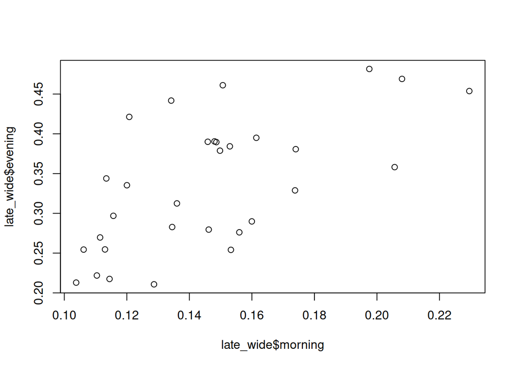

```r
# 2c-b) Correlation between morning and evening flights across days
# transpose to wide to get morning/evening columns
late_wide <- late_by_day %>%
  select(day, time_of_day, prop_late) %>%
  pivot_wider(names_from = time_of_day, values_from = prop_late)

plot(late_wide$morning, late_wide$evening) # plot
```

```r
cor(late_wide$morning, late_wide$evening) # correlation coefficient
```

```
## [1] 0.6321228
```

```r
# 2c-c) Report the average morning proportion, average evening proportion, and their product
avg_even_late <- mean(late_by_day$prop_late[late_by_day$time_of_day == "evening"])
median(late_by_day$prop_late[late_by_day$time_of_day == "evening"])
```

```
## [1] 0.3353353
```

```r
sd(late_by_day$prop_late[late_by_day$time_of_day == "evening"])
```

```
## [1] 0.08204352
```

```r
IQR(late_by_day$prop_late[late_by_day$time_of_day == "evening"])
```

```
## [1] 0.1173069
```

```r
avg_morn_late <- mean(late_by_day$prop_late[late_by_day$time_of_day == "morning"])
median(late_by_day$prop_late[late_by_day$time_of_day == "morning"])
```

```
## [1] 0.1461891
```

```r
sd(late_by_day$prop_late[late_by_day$time_of_day == "morning"])
```

```
## [1] 0.03222289
```

```r
IQR(late_by_day$prop_late[late_by_day$time_of_day == "morning"])
```

```
## [1] 0.04011927
```

```r
avg_morn_late * avg_even_late
```

```
## [1] 0.04913409
```

```r
# 2c-d) Estimate p(Morning Flight late & Evening Flight late on same day) as average over days
average_of_prod <- mean(late_wide$morning * late_wide$evening) # p(late morning & evening | any given day)
prod_of_averages <- avg_morn_late * avg_even_late # p(late morning AND late evening) assuming independence
average_of_prod
```

```
## [1] 0.05075131
```

```r
prod_of_averages
```

```
## [1] 0.04913409
```

```r
average_of_prod - prod_of_averages
```

```
## [1] 0.001617223
```

```r
# small difference in probabilities = not mathematically independent
# demonstrates independence of morning vs evening lateness in principle
```

# Part 3 · A rule that works, and the same rule that does not (22 points)

## (3a) Arriving more than 15 minutes late

```r
flag <- d$dep_delay > 30
act_late <- d$arr_delay > 15

pF <- mean(flag)
pL <- pA

table(Flagged = flag,
      Late = act_late)
```

```
##        Late
## Flagged  FALSE   TRUE
##   FALSE 247167  32274
##   TRUE    2549  45356
```

```r
# Sensitivity: True positive, probability that the flight was flagged given that it was actually late
#   p(F | L)
pFgL <- mean(flag[act_late])
pFgL
```

```
## [1] 0.5842587
```

```r
# Specificity: True negative, probability that the flight wasn't flagged given that it was on time
#   p(Fc | Lc)
pFcgLc <- mean(!flag[!act_late])
pFcgLc
```

```
## [1] 0.9897924
```

```r
# Precision: Probability that the flight was actually late, given that it was flagged
#   p(L | F)
pLgF <- mean(act_late[flag])
pLgF
```

```
## [1] 0.9467905
```

## (3b) Arriving more than three hours late

```r
# New Late time
act_late180 <- d$arr_delay > 180
pact_late180 <- mean(act_late180)

# Sensitivity: True positive, probability that the flight was flagged given that it was actually late
#   p(F | L)

pFgL180 <- mean(flag[act_late180])
pFgL180
```

```
## [1] 0.9997398
```

```r
# Specificity: True negative, probability that the flight wasn't flagged given that it was on time
#   p(Fc | Lc)
pFcgL180c <- mean(!flag[!act_late180])
pFcgL180c
```

```
## [1] 0.8637942
```

```r
# Precision: Probability that the flight was actually late, given that it was flagged
#   p(L | F)
pL180gF <- mean(act_late180[flag])
pL180gF
```

```
## [1] 0.0802004
```

## (3c) The same precision, by Bayes’ rule

```r
# p(L180 | F) = [p(F | L180)p(L180)] / p(F)

pL180gF_bayes <- (pFgL180 * pact_late180) / pF
pL180gF_bayes
```

```
## [1] 0.0802004
```

## (3d) For the manager

# Part 4 · Which distribution, and why not (22 points)

## (4a) Cancellations and scheduled departures

- Cancellations: Daily mean = 266.29; Daily variance = 29999.75. This indicates overdispersion where the rate of cancellations isn’t constant or the probability of a cancellation is not independent.
- Daily JFK flights at 5PM: Daily mean = 281.35; Daily variance = 485.64. This includes all 31 days and still shows over-dispersion. When reducing the sample to 28 days - daily mean = 286.68; daily variance = 10.23 (Poisson fails in the opposite direction - underdispersion). Considering that we’re looking at a specific time across days, the process that produces a poisson distribution where mean = variance is broken because the rate of the process (flights per day at 5PM) is fixed rather than random or independent.
- Difference in dispersion between 31 days and 28 days for flights at 5PM out of JFK: Not all months have 31 days, so mean and variance when calculated for 31 days is probably biased upward for months that have more data (more days). The difference between mean and variance isn’t as large as it is for cancellations because we’ve taken a smaller sample (JFk at 5PM), rather than all aiports over a 24 hour period of time.

```r
# Count flights with missing dep_time for each day
cancellations <- flights %>%
  filter(is.na(dep_time)) %>%
  group_by(day) %>%
  summarise(n = n(), .groups = "drop")
cancellations
```

```
## # A tibble: 31 × 2
##      day     n
##    <int> <int>
##  1     1   246
##  2     2   250
##  3     3   109
##  4     4    82
##  5     5   226
##  6     6   296
##  7     7   318
##  8     8   921
##  9     9   593
## 10    10   535
## # ℹ 21 more rows
```

```r
cancellations_summary <- cancellations %>%
  summarise(daily_mean = mean(n), daily_var = var(n))
cancellations_summary
```

```
## # A tibble: 1 × 2
##   daily_mean daily_var
##        <dbl>     <dbl>
## 1       266.    30000.
```

```r
# Count flights from JFK with hour == 17 for each day
sched_dept_jfk <- flights %>%
  filter(origin == "JFK", hour == 17) %>%
  group_by(day) %>%
  summarize(n = n(), .groups = "drop")
sched_dept_jfk
```

```
## # A tibble: 31 × 2
##      day     n
##    <int> <int>
##  1     1   290
##  2     2   288
##  3     3   289
##  4     4   286
##  5     5   285
##  6     6   285
##  7     7   286
##  8     8   286
##  9     9   283
## 10    10   286
## # ℹ 21 more rows
```

```r
# Over-dispersion with all 31 days
sched_dept_jfk_summary <- sched_dept_jfk %>%
  summarise(daily_mean = mean(n), daily_var = var(n))
sched_dept_jfk_summary
```

```
## # A tibble: 1 × 2
##   daily_mean daily_var
##        <dbl>     <dbl>
## 1       281.      486.
```

```r
# Under-dispersion with fewer days
sched_dept_jfk %>%
  filter(day <= 28) %>%
  summarise(daily_mean = mean(n), daily_var = var(n))
```

```
## # A tibble: 1 × 2
##   daily_mean daily_var
##        <dbl>     <dbl>
## 1       287.      10.2
```

## (4b) Late flights per day, JFK to LAX

A binomial distribtuion assumes independence between flights (which is not waht is actually observed), and constant probability across flights (which also isn’t observed since flights aren’t independent, statistically). Thus, observed variance does not match what we would otherwise expect under those assumptions. Patterns in flight cancellations are correlated at some level - weather, scheduling, etc.

```r
# Binomial Distribution
# n = No. of observations (trials)
# p = probability of an event (e.g. late flight)
# mean = np
# variance = np(1-p)

# Assumptions:
# 1) Fixed number of trials, n
# 2) Independence between trials
# 3) Constant probability of event across all trials, p

d_jfk_lax <- d %>%
  filter(origin == "JFK", dest == "LAX")

# Pooled rate across all days
p_hat_late_jfk_lax <- mean(d_jfk_lax$arr_delay > 15)   # probability of: event = late
n_total_jfk_lax     <- length(d_jfk_lax$arr_delay)      # total no. of flights, all days
p_hat_late_jfk_lax
```

```
## [1] 0.1915942
```

```r
# Per day
daily_jfk_lax <- d_jfk_lax %>%
  group_by(day) %>%
  summarise(total = n(),
            n_late = sum(arr_delay > 15),
            .groups = "drop") %>%
  mutate(theoretical_var = total * p_hat_late_jfk_lax * (1 - p_hat_late_jfk_lax))

observed_var <- var(daily_jfk_lax$n_late)
observed_var
```

```
## [1] 436.4323
```

```r
avg_theoretical_var <- mean(daily_jfk_lax$theoretical_var)
avg_theoretical_var
```

```
## [1] 55.75392
```

## (4c) The 68-95-99.7 rule, twice

```r
# 68-98-99.7 for d$arr_delay
arr <- d$arr_delay
m_arr <- mean(arr)
s_arr <- sd(arr)

emp_rule <- function(x, m, s, k) { # arguments: x = vector, m = mean, s = SD, k = # of SDs
  mean(x >= m - k*s & x <= m + k*s)
}

sapply(1:3, \(k) emp_rule(arr, m_arr, s_arr, k)) # check SD 1- 3 as k using emp_rule() on d$arr_delay and air_time
```

```
## [1] 0.8746403 0.9544305 0.9777453
```

```r
# 68-95-99.7 for d_jfk_lax$air_time
air <- d_jfk_lax$air_time
m_air <- mean(air)
s_air <- sd(air)

sapply(1:3, \(k) emp_rule(air, m_air, s_air, k))
```

```
## [1] 0.6878753 0.9589569 0.9975804
```

```r
# air_time passes
pnorm_air <- 1 - pnorm(360, mean = m_air, sd = s_air)
pnorm_air
```

```
## [1] 0.04478558
```

```r
actual_air <- mean(air > 360)
actual_air
```

```
## [1] 0.0422977
```

```r
pnorm_air - actual_air
```

```
## [1] 0.00248788
```

```r
# arr_delay fails
pnorm_delay <- pnorm(-30, mean = m_arr, sd = s_arr)
pnorm_delay
```

```
## [1] 0.2042224
```

```r
actual_delay <- mean(d$arr_delay < -30)
actual_delay
```

```
## [1] 0.06135404
```

```r
pnorm_delay - actual_delay
```

```
## [1] 0.1428684
```

# Part 5 · < or ≤ (8 points)

## (5a) The daily late count

P(X < 5) = 0.5232877 P(X <= 5) = 0.5972603 Since we are working with a binomial distribution, P(X = 5) can be specifically calculated which results in the difference between P(X < 5) and P(X <= 5).

```r
daily_jfk_lax <- d_jfk_lax %>%
  group_by(month, day) %>%
  summarise(total = n(),
            n_late = sum(arr_delay > 15),
            .groups = "drop") %>%
  mutate(theoretical_var = total * p_hat_late_jfk_lax * (1 - p_hat_late_jfk_lax))

n_late <- daily_jfk_lax$n_late

p_less5 <- mean(n_late < 5)     # P(X < 5)
p_leq5   <- mean(n_late <= 5)    # P(X <= 5)

p_less5
```

```
## [1] 0.5232877
```

```r
p_leq5
```

```
## [1] 0.5972603
```

## (5b) air_time

```r
p_less330 <- mean(d_jfk_lax$air_time < 330,  na.rm = TRUE)
p_le330   <- mean(d_jfk_lax$air_time <= 330, na.rm = TRUE)

p_less330
```

```
## [1] 0.5116946
```

```r
p_le330
```

```
## [1] 0.5317681
```

# Part 6 · The staffing sentence (10 points)

The flights aren’t independent due to weather, airport problems, domino effect from problems of other flight, etc. In 4b the actual, observed variance (436.4323) differed substantially from what would be expected (55.75392) if flights were truly independent. On days where more flights are cancelled, the airports will be understaffed and uneventful days will be overstaffed because of the high degree of variability.

# AI disclosure

## Prompt log

https://claude.ai/chat/29211949-5478-4121-9a31-d20bb9171729